# Module 8 Assignment: BEAST_tutorial

Liam McCrea

2023-11-07

# Purpose

Walk through the functions of BEAST2 for phylogenetic tree building. Learn the necessary programs and how they work, and practice interpreting results.

# Results

By interpreting the final tree, densitree, and initial QC plots, our tree building procedure appears to provide a quality tree.

## initial QC plots

[figure not shown]

## FigTrees

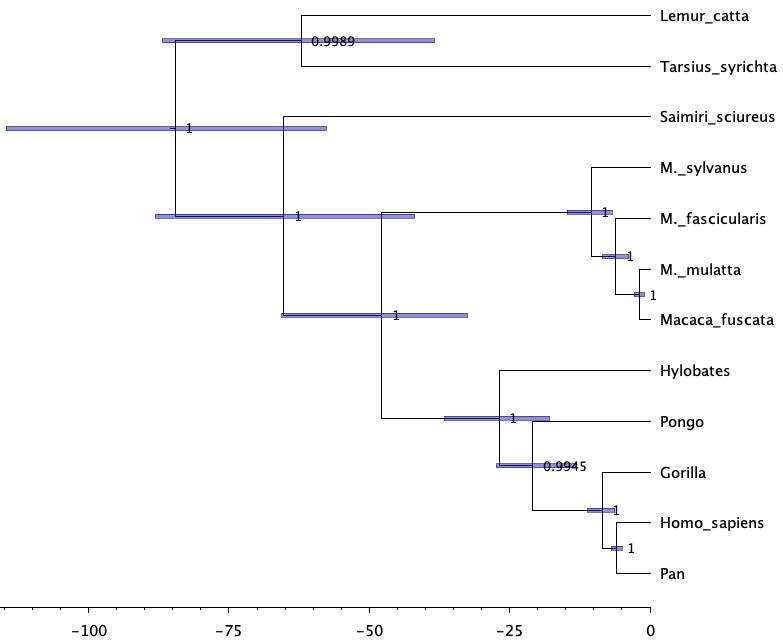

## DensiTrees

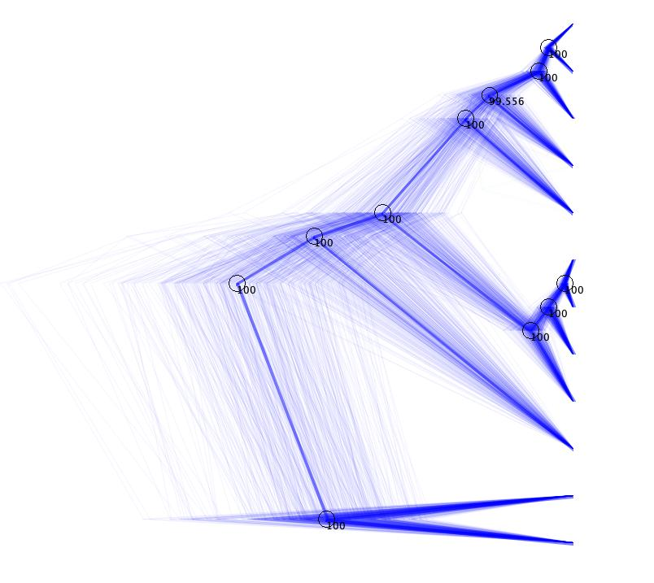

# Methods

## Input Data

The input data is alignment data combined with metadata in the form of a nexus file. The data includes twelve primate mitochondrial genomes.

## Programs used

- BEAST2: constructs phylogenetic trees
- BEAUti2: generates .xml configuration file for running BEAST2
- TreeAnnotator: produces maximum clade credibility tree.
- Tracer: summarise estimates of parameters of markov chain.
- FigTree: produces publication quality figures.
- DensiTree: estimates uncertainty of tree in space and creates representation figure.

## Partitions and Models

The data is partitioned into 4 partitions: 1. non-coding regions 2. 1st coding regions 3. 2nd coding regions 4. 3rd coding regions

We direct BEAST2 to use the Gamma site mode with a linked clock model and tree, and substitution model.

## Priors

We set up the birthRateY.t:tree parameter with unspecific Gamma prior - this measures rate of speciation.

We add a calibration node using a MRCA prior set to the human and chimp split.

## MCMC

We set the chain length to 10,000 and the Tracelog to 200. Following up the first analysis we also compare to a run using 100,000 chain length and log every 1000.

We run BEAST2 with random number seed 777.

## Tracer

We analyze the results in tracer. Plots are exported.

## Tree Creation

Using FigTree we can visualize our tree. Using DensiTree we can visualize the overall distribution of trees.

# References

- Bouckaert, Remco, Timothy G. Vaughan, Joëlle Barido-Sottani, Sebastián Duchêne, Mathieu Fourment, Alexandra Gavryushkina, Joseph Heled, et al. 2019. “BEAST 2.5: An Advanced Software Platform for Bayesian Evolutionary Analysis.” PLOS Computational Biology 15 (4): e1006650..
- Joëlle Barido-Sottani, Veronika Bošková, Louis du Plessis, Denise Kühnert, Carsten Magnus, Venelin Mitov, Nicola F. Müller, Jūlija Pečerska, David A. Rasmussen, Chi Zhang, Alexei J. Drummond, Tracy A. Heath, Oliver G. Pybus, Timothy G. Vaughan, Tanja Stadler (2018). Taming the BEAST – A community teaching material resource for BEAST 2. Systematic Biology, 67(1), 170–-174. doi: 10.1093/sysbio/syx060
- Rambaut A, Drummond AJ, Xie D, Baele G and Suchard MA (2018) Posterior summarisation in Bayesian phylogenetics using Tracer 1.7. Systematic Biology. syy032. doi:10.1093/sysbio/syy032
- Rambaut, A. (2009). FigTree: Tree figure drawing tool, version 1.4.4. Institute of Evolutionary Biology, University of Edinburgh.